# Recursos Técnicos Hospitalarios

Alicia Perdices Guerra

3 de mayo, 2021

#### **1.PROCESAMIENTO DE LOS DATOS.**

- En primer lugar leemos el fichero:

```r
recursos<-read.csv("C:/temp/RecursosTecnicos_hospitalarios.csv",sep= ",")
```

- Realicemos una breve inspección de los datos

```r
str(recursos)
```

```
## 'data.frame':    1860 obs. of  6 variables:
##  $ TIME              : int  2010 2010 2010 2010 2010 2010 2010 2010 2010 2010 ...
##  $ GEO               : Factor w/ 31 levels "Austria","Belgium",..: 2 2 2 2 2 2 3 3 3 3 ...
##  $ FACILITY          : Factor w/ 6 levels "Day care places altogether",..: 4 1 6 3 5 2 4 1 6 3 ...
##  $ UNIT              : Factor w/ 1 level "Number": 1 1 1 1 1 1 1 1 1 1 ...
##  $ Value             : Factor w/ 616 levels ":","0.00","1 014.00",..: 29 451 184 46 197 475 1 1 1 1 ...
##  $ Flag.and.Footnotes: Factor w/ 5 levels "","b","d","e",..: 1 1 1 1 1 1 1 1 1 1 ...
```

```r
colnames(recursos) #Nombre de las variables
```

```
## [1] "TIME"               "GEO"                "FACILITY"
## [4] "UNIT"               "Value"              "Flag.and.Footnotes"
```

```r
nrow(recursos) #Número de registros
```

```
## [1] 1860
```

```r
ncol(recursos) #Número de variables
```

```
## [1] 6
```

*Observamos las siguientes variables:

- **TIME**: variable cuantitativa. Indica el año en el que se ha realizado la medida, en este caso el valor de la variable “Value”. Se ha cargado bien como número entero.
- **GEO**: variable cualitativa. Indica el país o región en el que se ha realizado la medida.Se ha cargado bien como factor.
- **UNIT**: variable cualitativa. Indica la medida de la variable valor.Se ha cargado bien como factor.
- **FACILITY**: variable cualitativa. Indica el tipo de recurso hospitalario.
- **Value**: Variable cuantitativa. Indica el número de recursos hospitalarios por países.Se ha cargado mal como factor.
- **Fal.and.footnotes**. Notas sobre etiquetas. Eliminamos esta columna.

*Años de las mediciones:

```r
unique(recursos$TIME)
```

```
##  [1] 2010 2011 2012 2013 2014 2015 2016 2017 2018 2019
```

*Paises:

```r
unique(recursos$GEO)
```

```
##  [1] Belgium
##  [2] Bulgaria
##  [3] Czechia
##  [4] Denmark
##  [5] Germany (until 1990 former territory of the FRG)
##  [6] Estonia
##  [7] Ireland
##  [8] Greece
##  [9] Spain
## [10] France
## [11] Croatia
## [12] Italy
## [13] Cyprus
## [14] Latvia
## [15] Lithuania
```

[output cut: 17 more lines]

*Unidad de las mediciones:

```r
unique(recursos$UNIT)
```

```
## [1] Number
## Levels: Number
```

- Tipo de recursos:

```r
unique(recursos$FACILITY)
```

```
## [1] Operation theatres in hospital Day care places altogether
## [3] Surgical day care places       Oncological day care place
## [5] Psychiatric day care place     Geriatric day care places
## 6 Levels: Day care places altogether ... Surgical day care places
```

- Eliminamos la columna Fal.and.footnotes.

```r
recursos<-recursos[,-6]
```

- Tendríamos que convertir la columna Value a numérico porque se ha cargado como factor y es erróneo. El resto de variables tienen el tipo correcto.

```r
recursos$Value<-as.character(recursos$Value)
recursos$Value<-(gsub(',','.',recursos$Value) )
recursos$Value<-(gsub(' ','',recursos$Value) )
recursos$Value<-as.numeric(recursos$Value)
```

- Comprobamos que valores tenemos en la columna **Value**:

```r
tail(table(recursos$Value, useNA = "ifany"))
```

```
##
## 72536 72789 74646 75452 77297  <NA>
##     1     1     1     1     1  1030
```

- Observamos que tenemos **1030 valores perdidos**.Guardamos en la variable **idx** los índices de los registros con valores **NA** de la variable **Value**.

```r
idx<-which(is.na(recursos$Value))
length(idx)
```

```
## [1] 1030
```

- Grafiquemos la información que contiene la variable **Value**

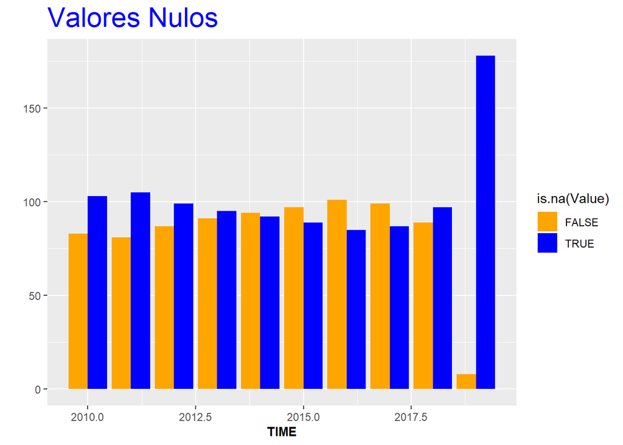

```r
library(ggplot2)
library(scales)
g = ggplot(recursos, aes(TIME, fill=is.na(Value)) ) +
labs(title = "Valores Nulos")+ylab("") +
theme(plot.title = element_text(size = rel(2), colour = "blue"))

g+geom_bar(position="dodge") + scale_fill_manual(values = alpha(c("orange", "blue"), 1)) +
theme(axis.title.x = element_text(face="bold", size=10))
```

- En caso de detectar algún valor anómalo (en nuestro caso los NAS) en las variables tendríamos que realizar una imputación de esos valores o bien sustituyéndolos por la media o usando el algoritmo KNN ( k-Nearest Neighbour) con los 3 vecinos más cercanos usando la distancia que consideremos, en este caso usaremos Gower(Mediana), por ser una medida más robusa frente a extremos.

```r
library(VIM)
output<-kNN(recursos, variable=c("Value"),k=3)
recursos<-output
```

- Comprobamos que no tenemos valores nulos después de la imputación

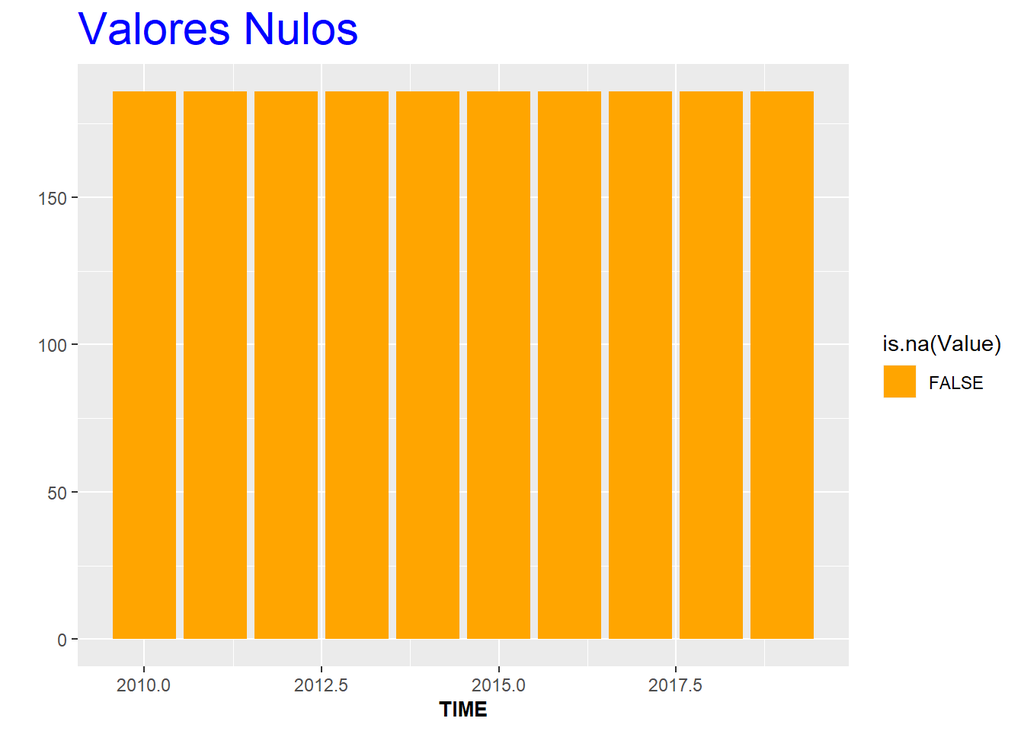

```r
g = ggplot(recursos, aes(TIME, fill=is.na(Value)) ) +
labs(title = "Valores Nulos")+ylab("") +
theme(plot.title = element_text(size = rel(2), colour = "blue"))

g+geom_bar(position="dodge") + scale_fill_manual(values = alpha(c("orange", "blue"), 1)) +
theme(axis.title.x = element_text(face="bold", size=10))
```

- Con el siguiente gráfico, observaremos que la variable **Value** tiene outliers o valores extremos

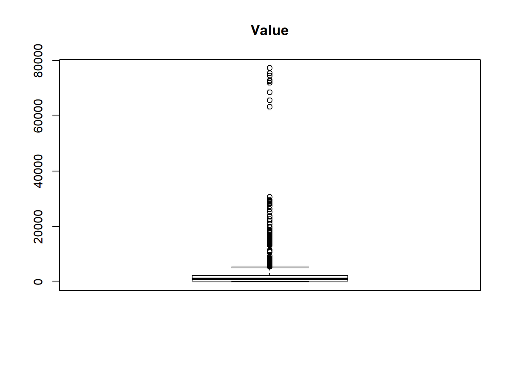

```r
boxplot(recursos$Value, main="Value")
```

- Por otro lado, revisamos para el resto de columnas si tenemos valores NA.(desconocidos o perdidos)

```r
table(recursos$TIME, useNA = "ifany")
```

```
##
## 2010 2011 2012 2013 2014 2015 2016 2017 2018 2019
##  186  186  186  186  186  186  186  186  186  186
```

```r
table(recursos$GEO, useNA = "ifany")
```

```
##
##                                          Austria
##                                               60
##                                          Belgium
##                                               60
##                                         Bulgaria
##                                               60
##                                          Croatia
##                                               60
##                                           Cyprus
##                                               60
##                                          Czechia
##                                               60
##                                          Denmark
##                                               60
##                                          Estonia
##                                               60
##                                           France
##                                               60
## Germany (until 1990 former territory of the FRG)
##                                               60
##                                           Greece
##                                               60
##                                          Hungary
##                                               60
##                                          Ireland
##                                               60
##                                            Italy
##                                               60
##                                           Latvia
##                                               60
##                                    Liechtenstein
##                                               60
##                                        Lithuania
##                                               60
##                                       Luxembourg
##                                               60
##                                            Malta
##                                               60
##                                      Netherlands
```

[output cut: 8 more lines]

```
##                                               60
##                                           Serbia
##                                               60
##                                         Slovakia
##                                               60
##                                         Slovenia
##                                               60
##                                            Spain
##                                               60
##                                      Switzerland
##                                               60
##                                           Turkey
##                                               60
##                                   United Kingdom
##                                               60
```

```r
table(recursos$UNIT, useNA = "ifany")
```

```
##
## Number
##   1860
```

```r
table(recursos$FACILITY, useNA = "ifany")
```

```
##
##     Day care places altogether      Geriatric day care places
##                            310                            310
##     Oncological day care place Operation theatres in hospital
##                            310                            310
##     Psychiatric day care place       Surgical day care places
##                            310                            310
```

Observamos que no existen ahora valores perdidos después de la imputación.La suma de las cantidades de cada variable, suman el total.

- Finalmente, creamos un fichero con toda la información corregida.

```r
write.csv(recursos, file="RecursosTecnicos_hospitalarios_clean.csv", row.names = FALSE)
```